# IODS course project

Suvi Järvinen

# About the project

# My current thoughts

Still feeling excited about this course! It was fun to see in the DataCamp exercises how R differs from Python as a language. I think the timetable for this course could have been more clear - it took some extra effort to figure out the actual deadlines for the exercise submissions and peer-reviews. Anyhow, I expect to learn in this course how to use R for data analysis, which should prove *very* useful in the future.

# Link

Here’s the link to my GitHub repository: https://github.com/saejarvi/IODS-project

# Test picture

[figure not shown]

R Short and Sweet certificate

# Exercise 2: Analysis

*Describe the work you have done this week and summarize your learning.*

- Describe your work and results clearly.
- Assume the reader has an introductory course level understanding of writing and reading R code as well as statistical methods.
- Assume the reader has no previous knowledge of your data or the more advanced methods you are using.

*Insert all the codes, your interpretations and explanations*

## TASK 1

## Reading the data into R and checking the structure and the dimensions of the data

```r
data <- read.table("data/learning2014.txt", sep=" ")
str(data)
```

```
## 'data.frame':    166 obs. of  7 variables:
##  $ Age     : int  53 55 49 53 49 38 50 37 37 42 ...
##  $ Points  : int  25 12 24 10 22 21 21 31 24 26 ...
##  $ gender  : Factor w/ 2 levels "F","M": 1 2 1 2 2 1 2 1 2 1 ...
##  $ attitude: num  3.7 3.1 2.5 3.5 3.7 3.8 3.5 2.9 3.8 2.1 ...
##  $ deep    : num  3.58 2.92 3.5 3.5 3.67 ...
##  $ stra    : num  3.38 2.75 3.62 3.12 3.62 ...
##  $ surf    : num  2.58 3.17 2.25 2.25 2.83 ...
```

```r
dim(data)
```

```
## [1] 166   7
```

*The dataset I’m using in these analyses is a subset of the dataset provided by Kimmo Vehkalahti. The original data (N=183) was collected during the course Introduction to Social Sciences at the University of Helsinki in 2014-2015. The study was conducted in Finnish. Using the ASSIST (Approaches and Study Skills Inventory) questionnaire, the participating students were asked about e.g. their learning approaches (deep, strategic, and surface approach). Their global attitude towards statistics was measured using the SATS (Survey of Attitudes Toward Statistics) questionnaire. Each student’s age and gender were included, as was their learning achievement measured by points they got in the course exam.*

*For the current analyses, I removed the students who got 0 points in the exam. Thus, the dataset has 166 observations and the 7 variables (Age, Points, gender, attitude, deep, stra, surf) described above.*

## TASK 2

## Graphical overview of the data and a summary of data

I installed the packages ggplot2, GGally and psych.

```r
library("ggplot2")
library("GGally")
library("psych")
```

### Advanced plot matrix and descriptive statistics:

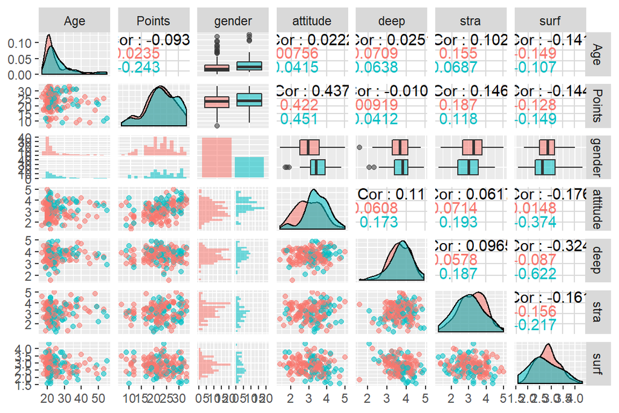

```r
matrix <- ggpairs(data, mapping = aes(col = gender, alpha = 0.3), lower = list(combo = wrap("facethist", bins = 20)))
matrix
```

```r
summary(data) #all participants
```

```
##       Age            Points      gender     attitude          deep
##  Min.   :17.00   Min.   : 7.00   F:110   Min.   :1.400   Min.   :1.583
##  1st Qu.:21.00   1st Qu.:19.00   M: 56   1st Qu.:2.600   1st Qu.:3.333
##  Median :22.00   Median :23.00           Median :3.200   Median :3.667
##  Mean   :25.51   Mean   :22.72           Mean   :3.143   Mean   :3.680
##  3rd Qu.:27.00   3rd Qu.:27.75           3rd Qu.:3.700   3rd Qu.:4.083
##  Max.   :55.00   Max.   :33.00           Max.   :5.000   Max.   :4.917
##       stra            surf
##  Min.   :1.250   Min.   :1.583
##  1st Qu.:2.625   1st Qu.:2.417
##  Median :3.188   Median :2.833
##  Mean   :3.121   Mean   :2.787
##  3rd Qu.:3.625   3rd Qu.:3.167
##  Max.   :5.000   Max.   :4.333
```

```r
describeBy(data, group="gender") #using the psych library to get a summary of the data divided by gender
```

```
##
##  Descriptive statistics by group
## group: F
##          vars   n  mean   sd median trimmed  mad   min   max range  skew
## Age         1 110 24.85 7.36  22.00   23.38 2.97 17.00 53.00 36.00  1.82
## Points      2 110 22.33 5.83  23.00   22.61 5.93  7.00 33.00 26.00 -0.36
## gender*     3 110  1.00 0.00   1.00    1.00 0.00  1.00  1.00  0.00   NaN
## attitude    4 110  2.99 0.73   2.95    2.98 0.82  1.40  5.00  3.60  0.14
## deep        5 110  3.66 0.53   3.67    3.68 0.62  1.58  4.75  3.17 -0.55
## stra        6 110  3.20 0.75   3.25    3.22 0.83  1.38  5.00  3.62 -0.15
## surf        7 110  2.83 0.46   2.83    2.82 0.49  1.83  4.00  2.17  0.19
##          kurtosis   se
## Age          2.83 0.70
## Points      -0.26 0.56
## gender*       NaN 0.00
## attitude    -0.52 0.07
## deep         0.90 0.05
## stra        -0.34 0.07
## surf        -0.43 0.04
## --------------------------------------------------------
## group: M
##          vars  n  mean   sd median trimmed  mad   min   max range  skew
## Age         1 56 26.80 8.43  24.00   25.11 4.45 19.00 55.00 36.00  1.90
## Points      2 56 23.48 6.01  23.50   24.00 6.67  9.00 33.00 24.00 -0.51
## gender*     3 56  2.00 0.00   2.00    2.00 0.00  2.00  2.00  0.00   NaN
## attitude    4 56  3.44 0.65   3.40    3.47 0.59  1.70  4.80  3.10 -0.45
## deep        5 56  3.72 0.59   3.79    3.75 0.49  2.08  4.92  2.83 -0.47
## stra        6 56  2.96 0.80   3.00    2.96 0.93  1.25  4.50  3.25  0.02
## surf        7 56  2.70 0.64   2.62    2.69 0.62  1.58  4.33  2.75  0.29
##          kurtosis   se
## Age          3.06 1.13
## Points      -0.29 0.80
## gender*       NaN 0.00
## attitude     0.48 0.09
## deep         0.19 0.08
## stra        -0.67 0.11
## surf        -0.60 0.09
```

*The majority of the students were female (female n=110, male n=56). Based on the plots, the distributions of age, exam points and deep learning seem very similar in both genders; the majority were young adults (75% were under 27 years old, range 17-55 years), half of the participants got at least 23.0 points from the exam (range 7-33 points), and deep learning strategy was favored (50% scored 3.667 or higher, range 1.583-4.917).*

*As for the between-gender differences, attitude towards statistics seems more positive among male participants (F median = 2.95, M median = 3.40). Female students seem to lean just a bit more towards using strategic learning (F median = 3.25, M median = 3.00), but also towards using surface learning (F median = 2.83, M median = 2.62).*

## TASKS 3 & 4

## Regression model summary

Based on the correlations between the continuous variables, I chose attitude towards statistics, using strategic learning and surface learning as explanatory variables. Exam points was used as the dependent variable.

```r
#The regression model:
regr_model <- lm(Points ~ attitude + stra + surf, data = data)
summary(regr_model)
```

```
##
## Call:
## lm(formula = Points ~ attitude + stra + surf, data = data)
##
## Residuals:
##      Min       1Q   Median       3Q      Max
## -17.1550  -3.4346   0.5156   3.6401  10.8952
##
## Coefficients:
##             Estimate Std. Error t value Pr(>|t|)
## (Intercept)  11.0171     3.6837   2.991  0.00322 **
## attitude      3.3952     0.5741   5.913 1.93e-08 ***
## stra          0.8531     0.5416   1.575  0.11716
## surf         -0.5861     0.8014  -0.731  0.46563
## ---
## Signif. codes:  0 '***' 0.001 '**' 0.01 '*' 0.05 '.' 0.1 ' ' 1
##
## Residual standard error: 5.296 on 162 degrees of freedom
## Multiple R-squared:  0.2074, Adjusted R-squared:  0.1927
## F-statistic: 14.13 on 3 and 162 DF,  p-value: 3.156e-08
```

*The model is statistically significant (p<0.001, F=14.13, df=162). However, of the three explanatory variables, the attitude variable is the only one with statistical significance (p<0.001). This model covers ~20% of the variance in the exam points, so ~80% of the variance is left “unexplained”.*

```r
#A new model without surface learning:
regr_model2 <- lm(Points ~ attitude + stra, data = data)
summary(regr_model2)
```

```
##
## Call:
## lm(formula = Points ~ attitude + stra, data = data)
##
## Residuals:
##      Min       1Q   Median       3Q      Max
## -17.6436  -3.3113   0.5575   3.7928  10.9295
##
## Coefficients:
##             Estimate Std. Error t value Pr(>|t|)
## (Intercept)   8.9729     2.3959   3.745  0.00025 ***
## attitude      3.4658     0.5652   6.132 6.31e-09 ***
## stra          0.9137     0.5345   1.709  0.08927 .
## ---
## Signif. codes:  0 '***' 0.001 '**' 0.01 '*' 0.05 '.' 0.1 ' ' 1
##
## Residual standard error: 5.289 on 163 degrees of freedom
## Multiple R-squared:  0.2048, Adjusted R-squared:  0.1951
## F-statistic: 20.99 on 2 and 163 DF,  p-value: 7.734e-09
```

*In this model, attitude is strongly significant (p<0.001) and strategic learning non-significant at 0.05 level (p<0.1). Also this model covers ~20% of the variance in the exam points.*

```r
#The final model with only one explanatory variable:
regr_model3 <- lm(Points ~ attitude, data = data)
summary(regr_model3)
```

```
##
## Call:
## lm(formula = Points ~ attitude, data = data)
##
## Residuals:
##      Min       1Q   Median       3Q      Max
## -16.9763  -3.2119   0.4339   4.1534  10.6645
##
## Coefficients:
##             Estimate Std. Error t value Pr(>|t|)
## (Intercept)  11.6372     1.8303   6.358 1.95e-09 ***
## attitude      3.5255     0.5674   6.214 4.12e-09 ***
## ---
## Signif. codes:  0 '***' 0.001 '**' 0.01 '*' 0.05 '.' 0.1 ' ' 1
##
## Residual standard error: 5.32 on 164 degrees of freedom
## Multiple R-squared:  0.1906, Adjusted R-squared:  0.1856
## F-statistic: 38.61 on 1 and 164 DF,  p-value: 4.119e-09
```

*Conclusion: attitude counts!*

## TASK 5

## Diagnostic plots

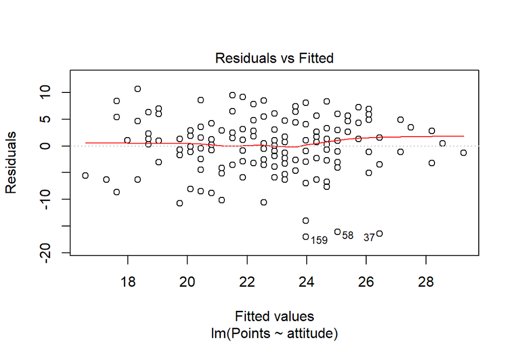

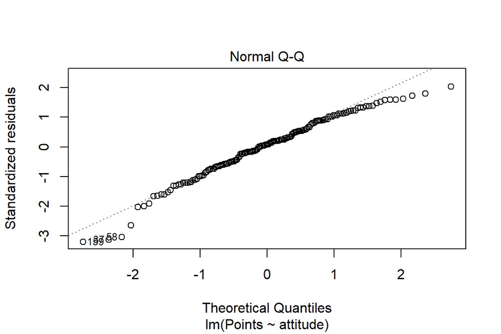

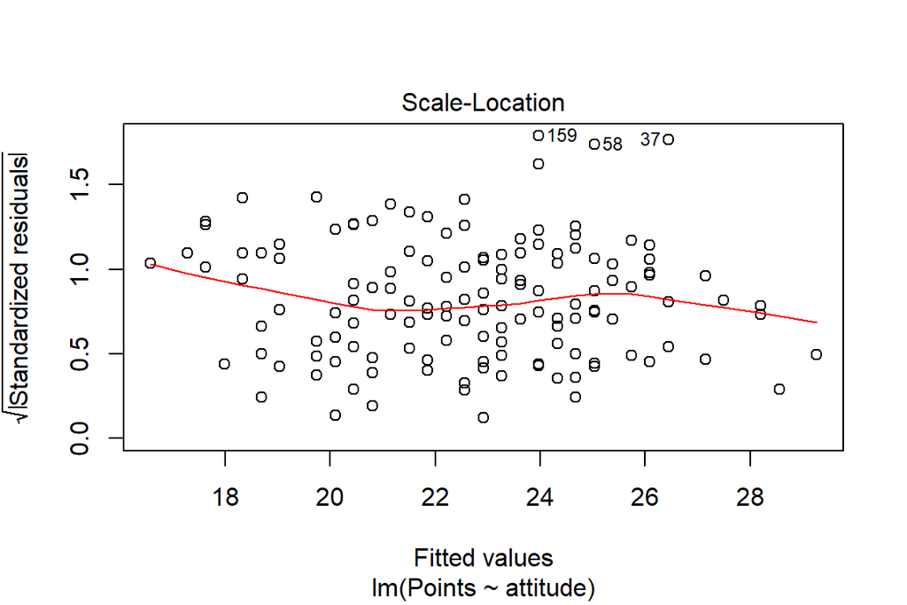

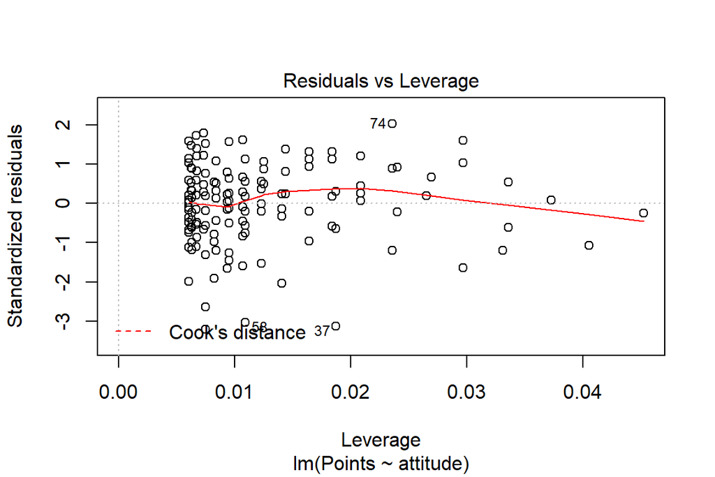

```r
plot(regr_model3)
```

Residuals vs. fitted values: *The residuals seem randomly distributed, so there is no dependency between residuals and the predicted values.*

Normal QQ-plot: *The standardized residuals deviate a bit from the plotline, but overall, the residuals are rather normally distributed. Our assumption that exam points are normally distributed seems to hold well.*

Residuals vs. Leverage: *All subjects are within Cook’s distance, i.e. there seem to be no cases having an especially strong influence on the regression analysis.*

*These plots speak for the robustness of our regression model, i.e. the assumptions of using the model are not violated.*

# Exercise 3: Analysis

## TASK 2

## Reading the data into R using the link provided:

```r
alc_data <- read.table("http://s3.amazonaws.com/assets.datacamp.com/production/course_2218/datasets/alc.txt", header=TRUE, sep=",")
str(alc_data)
```

```
## 'data.frame':    382 obs. of  35 variables:
##  $ school    : Factor w/ 2 levels "GP","MS": 1 1 1 1 1 1 1 1 1 1 ...
##  $ sex       : Factor w/ 2 levels "F","M": 1 1 1 1 1 2 2 1 2 2 ...
##  $ age       : int  18 17 15 15 16 16 16 17 15 15 ...
##  $ address   : Factor w/ 2 levels "R","U": 2 2 2 2 2 2 2 2 2 2 ...
##  $ famsize   : Factor w/ 2 levels "GT3","LE3": 1 1 2 1 1 2 2 1 2 1 ...
##  $ Pstatus   : Factor w/ 2 levels "A","T": 1 2 2 2 2 2 2 1 1 2 ...
##  $ Medu      : int  4 1 1 4 3 4 2 4 3 3 ...
##  $ Fedu      : int  4 1 1 2 3 3 2 4 2 4 ...
##  $ Mjob      : Factor w/ 5 levels "at_home","health",..: 1 1 1 2 3 4 3 3 4 3 ...
##  $ Fjob      : Factor w/ 5 levels "at_home","health",..: 5 3 3 4 3 3 3 5 3 3 ...
##  $ reason    : Factor w/ 4 levels "course","home",..: 1 1 3 2 2 4 2 2 2 2 ...
##  $ nursery   : Factor w/ 2 levels "no","yes": 2 1 2 2 2 2 2 2 2 2 ...
##  $ internet  : Factor w/ 2 levels "no","yes": 1 2 2 2 1 2 2 1 2 2 ...
##  $ guardian  : Factor w/ 3 levels "father","mother",..: 2 1 2 2 1 2 2 2 2 2 ...
```

[output cut: 21 more lines]

*The dataset has been downloaded from UCI Machine Learning Depository. The data have been collected from secondary education students in two Portuguese schools by using school reports and questionnaires. The data contain 35 variables that cover the students’ grades, democraphic, social and school-related measures.*

## TASK 3

*The aim of the current analyses is to study the relationships between high/non-high alcohol consumption (high_use) and some of the other variables in the data.*

*I chose the following 4 variables of interest for the analysis:* freetime - free time after school (numeric: from 1 - very low to 5 - very high) famrel - quality of family relationships (numeric: from 1 - very bad to 5 - excellent); goout - going out with friends (numeric: from 1 - very low to 5 - very high); health - current health status (numeric: from 1 - very bad to 5 - very good).

*My hypotheses are:* 1) high alcohol consumption is more probable in cases of having more freetime 2) high alcohol consumption is more probable in cases of bad family relationships vs. good relationships 3) high alcohol consumption is more probable in students who tend to go out with friends 4) high alcohol consumption is more probable in cases of worse current health status

## TASK 4

First checking how many a student uses non-high vs. high amounts of alcohol:

```r
library(dplyr); library(ggplot2); library(psych)
alc_data %>% group_by(high_use) %>% summarise(count = n())
```

```
## # A tibble: 2 x 2
##   high_use count
##   <lgl>    <int>
## 1 FALSE      270
## 2 TRUE       112
```

In this dataset, n=270 students have non-high, n=112 have high alcohol consumption.

Group frequencies of the 4 chosen variables:

```r
table(alc_data$freetime)
```

```
##
##   1   2   3   4   5
##  18  62 156 109  37
```

```r
table(alc_data$famrel)
```

```
##
##   1   2   3   4   5
##   9  18  66 183 106
```

```r
table(alc_data$goout)
```

```
##
##   1   2   3   4   5
##  24  99 123  82  54
```

```r
table(alc_data$health)
```

```
##
##   1   2   3   4   5
##  46  43  83  64 146
```

How the use of alcohol is divided among the groups of the 4 variables of interest:

```r
cross1 <- table(alc_data$high_use, alc_data$freetime)
round(prop.table(cross1,2)*100, digits=0) #percentages in each group
```

```
##
##          1  2  3  4  5
##   FALSE 89 76 74 63 59
##   TRUE  11 24 26 37 41
```

```r
cross2 <- table(alc_data$high_use, alc_data$famrel)
round(prop.table(cross2,2)*100, digits=0)
```

```
##
##          1  2  3  4  5
##   FALSE 78 50 61 72 78
##   TRUE  22 50 39 28 22
```

```r
cross3 <- table(alc_data$high_use, alc_data$goout)
round(prop.table(cross3,2)*100, digits=0)
```

```
##
##          1  2  3  4  5
##   FALSE 88 85 81 52 41
##   TRUE  12 15 19 48 59
```

```r
cross4 <- table(alc_data$high_use, alc_data$health)
round(prop.table(cross4,2)*100, digits=0)
```

```
##
##          1  2  3  4  5
##   FALSE 76 67 76 73 66
##   TRUE  24 33 24 27 34
```

Based on these contingency tables, it seems that a) as freetime increases (1->5), the probability of high alcohol consumption increases; b) as the quality of family relationships increases (1->5), the probability of high alcohol consumption first increases, then decreases; c) as going out with friends increases (1->5), the probability of high alcohol consumption increases; and d) as current health status increases (1->5), the probability of high alcohol consumption doesn’t change.

*My hypotheses were:* 1) high alcohol consumption is more probable in cases of having more freetime 2) high alcohol consumption is more probable in cases of bad family relationships vs. good relationships 3) high alcohol consumption is more probable in students who tend to go out with friends 4) high alcohol consumption is more probable in cases of worse current health status

This preliminary exploration seems to support my hypotheses 1) and 3), but not 2) and 4).

It is worth noting that the percentages can be misleading with very small number of cases (e.g. famrel=1, n=9).

## TASK 5

## Logistic regression models

```r
m_1 <- glm(high_use ~ freetime + famrel + goout + health, data = alc_data)
OR_1 <- coef(m_1) %>% exp
CI_1 <- confint(m_1) %>% exp
summary(m_1)
```

```
##
## Call:
## glm(formula = high_use ~ freetime + famrel + goout + health,
##     data = alc_data)
##
## Deviance Residuals:
##     Min       1Q   Median       3Q      Max
## -0.6235  -0.3021  -0.1617   0.4023   1.0652
##
## Coefficients:
##             Estimate Std. Error t value Pr(>|t|)
## (Intercept) -0.01266    0.12451  -0.102 0.919077
## freetime     0.03297    0.02306   1.430 0.153551
## famrel      -0.08620    0.02374  -3.631 0.000321 ***
## goout        0.14025    0.01991   7.044 8.89e-12 ***
## health       0.02869    0.01547   1.855 0.064393 .
## ---
## Signif. codes:  0 '***' 0.001 '**' 0.01 '*' 0.05 '.' 0.1 ' ' 1
##
## (Dispersion parameter for gaussian family taken to be 0.1760194)
##
##     Null deviance: 79.162  on 381  degrees of freedom
## Residual deviance: 66.359  on 377  degrees of freedom
## AIC: 427.44
##
## Number of Fisher Scoring iterations: 2
```

```r
cbind(OR_1, CI_1)
```

```
##                  OR_1     2.5 %    97.5 %
## (Intercept) 0.9874219 0.7736114 1.2603254
## freetime    1.0335187 0.9878552 1.0812930
## famrel      0.9174147 0.8757075 0.9611084
## goout       1.1505612 1.1065292 1.1963453
## health      1.0291043 0.9983761 1.0607783
```

Odds ratio refers to the ratio of two odds (in this case, the odds of having high/non-high alcohol consumption). OR = 1 means these two conditions are just as likely. The confidence interval shows the range the OR falls into with 95% probability (default).

According to this model, having a) more or less freetime or b) better or worse current health status makes no difference in terms of alcohol consumption (CI includes one).

On the other hand, both the quality of family relationships and the frequency of going out with friends seem to be valid predictors of the probability of high alcohol consumption (p<0.001 for both). Here, the first level of the outcome variable (FALSE) denotes failure and the other (TRUE) success. Because higher odds = higher probability of “success” and lower odds = lower probability of “success” vs. “failure”, it seems that better quality of family relationships is associated with slightly lower probability of high alcohol consumption. Conversely, more frequent going out with friends is associated with slightly higher probability of high alcohol consumption. These results support my hypotheses 2) and 3), but not 1) and 4).

## The model with only statistically significant predictors included:

```r
m_2 <- glm(high_use ~ famrel + goout, data = alc_data, family = "binomial")

#Analyzing the predictive power of the model:
prob <- predict(m_2, type = "response") #Creating object prob that indicates the predicted probabilities on the scale of the response var (high_use)
alc_data <- mutate(alc_data, probability = prob)  #Adding a new variable called probability to the dataset
alc_data <- mutate(alc_data, prediction = probability > 0.5) #Adding a new variable called prediction; TRUE if probability > 0.5

str(alc_data) #Checking how the dataset looks
```

```
## 'data.frame':    382 obs. of  37 variables:
##  $ school     : Factor w/ 2 levels "GP","MS": 1 1 1 1 1 1 1 1 1 1 ...
##  $ sex        : Factor w/ 2 levels "F","M": 1 1 1 1 1 2 2 1 2 2 ...
##  $ age        : int  18 17 15 15 16 16 16 17 15 15 ...
##  $ address    : Factor w/ 2 levels "R","U": 2 2 2 2 2 2 2 2 2 2 ...
##  $ famsize    : Factor w/ 2 levels "GT3","LE3": 1 1 2 1 1 2 2 1 2 1 ...
##  $ Pstatus    : Factor w/ 2 levels "A","T": 1 2 2 2 2 2 2 1 1 2 ...
##  $ Medu       : int  4 1 1 4 3 4 2 4 3 3 ...
##  $ Fedu       : int  4 1 1 2 3 3 2 4 2 4 ...
##  $ Mjob       : Factor w/ 5 levels "at_home","health",..: 1 1 1 2 3 4 3 3 4 3 ...
##  $ Fjob       : Factor w/ 5 levels "at_home","health",..: 5 3 3 4 3 3 3 5 3 3 ...
##  $ reason     : Factor w/ 4 levels "course","home",..: 1 1 3 2 2 4 2 2 2 2 ...
##  $ nursery    : Factor w/ 2 levels "no","yes": 2 1 2 2 2 2 2 2 2 2 ...
##  $ internet   : Factor w/ 2 levels "no","yes": 1 2 2 2 1 2 2 1 2 2 ...
##  $ guardian   : Factor w/ 3 levels "father","mother",..: 2 1 2 2 1 2 2 2 2 2 ...
```

[output cut: 23 more lines]

```r
#Predictions vs. actual values of alcohol consumption:
table(high_use = alc_data$high_use, prediction = alc_data$prediction)
```

```
##         prediction
## high_use FALSE TRUE
##    FALSE   243   27
##    TRUE     64   48
```

Total proportions of inaccurately classified individuals:

```r
proportion_inacc <- (64 + 27) / 382
proportion_inacc
```

```
## [1] 0.2382199
```

Based on the results, the model makes an inaccurate prediction in 23.8% of the cases.

```r
proportion_acc_false <- 243 / (243 + 64)
proportion_acc_false
```

```
## [1] 0.7915309
```

```r
proportion_acc_true <- 48 / (48 + 27)
proportion_acc_true
```

```
## [1] 0.64
```

The model predicts FALSE cases (low alcohol consumption) at 79.2% accuracy and TRUE cases (high alcohol consumption) at 64% accuracy. Therefore, the model is a more accurate predictor than, say, tossing a coin. However, this is surely not the best possible model to predict the probability of high alcohol use in this population.

# Exercise 4: Analysis

*In this week’s exercise, we use the linear discriminant analysis to predict an outcome (crime rate category) based on several predictor variables. We test the predictive power of the model with a test set (subset of the original data). This analysis helps in determining which variables discriminate the outcome categories best. Finally we use the clustering approach to try and determine the “best” number of clusters in the dataset.*

## TASK 2

## Loading the Boston data from the MASS package and checking the structure and the dimensions of the data

```r
library(MASS) #accessing the MASS package
data("Boston") #loading the data
str(Boston) #structure
```

```
## 'data.frame':    506 obs. of  14 variables:
##  $ crim   : num  0.00632 0.02731 0.02729 0.03237 0.06905 ...
##  $ zn     : num  18 0 0 0 0 0 12.5 12.5 12.5 12.5 ...
##  $ indus  : num  2.31 7.07 7.07 2.18 2.18 2.18 7.87 7.87 7.87 7.87 ...
##  $ chas   : int  0 0 0 0 0 0 0 0 0 0 ...
##  $ nox    : num  0.538 0.469 0.469 0.458 0.458 0.458 0.524 0.524 0.524 0.524 ...
##  $ rm     : num  6.58 6.42 7.18 7 7.15 ...
##  $ age    : num  65.2 78.9 61.1 45.8 54.2 58.7 66.6 96.1 100 85.9 ...
##  $ dis    : num  4.09 4.97 4.97 6.06 6.06 ...
##  $ rad    : int  1 2 2 3 3 3 5 5 5 5 ...
##  $ tax    : num  296 242 242 222 222 222 311 311 311 311 ...
##  $ ptratio: num  15.3 17.8 17.8 18.7 18.7 18.7 15.2 15.2 15.2 15.2 ...
##  $ black  : num  397 397 393 395 397 ...
##  $ lstat  : num  4.98 9.14 4.03 2.94 5.33 ...
##  $ medv   : num  24 21.6 34.7 33.4 36.2 28.7 22.9 27.1 16.5 18.9 ...
```

```r
dim(Boston) #dimensions
```

```
## [1] 506  14
```

*The data frame has 506 observations and 14 variables. The data have been collected in suburbs in Boston, and they include different housing values related variables, such as per capita crime rate, average number of rooms per dwelling etc., for each suburb studied. The variable descriptions can be found here: https://stat.ethz.ch/R-manual/R-devel/library/MASS/html/Boston.html.*

## TASK 3

## Graphical overview of the data, summaries of the variables

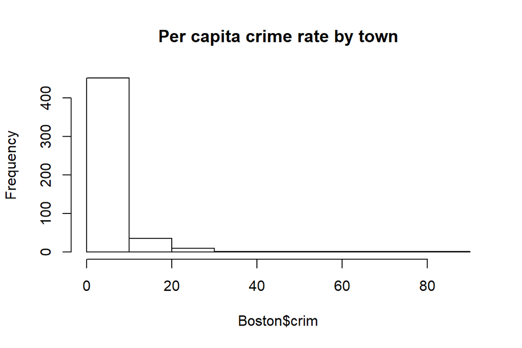

```r
library("GGally") #access to the GGally library and the ggpairs() function

#Histograms of the continuous variables:
hist(Boston$crim,main="Per capita crime rate by town")
```

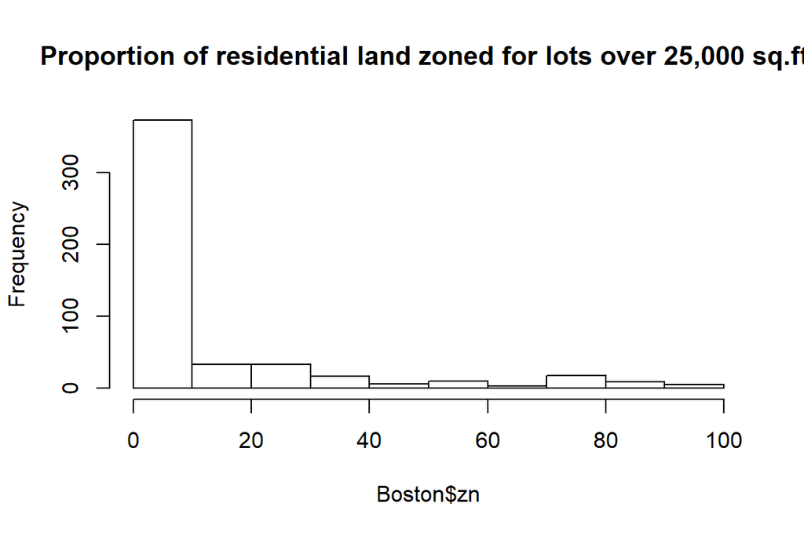

```r
hist(Boston$zn,main="Proportion of residential land zoned for lots over 25,000 sq.ft.")
```

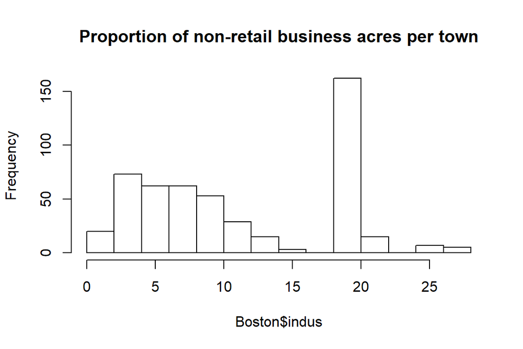

```r
hist(Boston$indus,main="Proportion of non-retail business acres per town")
```

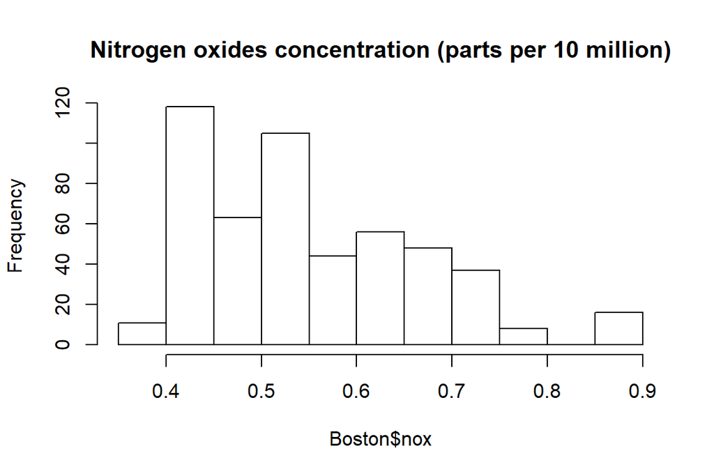

```r
hist(Boston$nox,main="Nitrogen oxides concentration (parts per 10 million)")
```

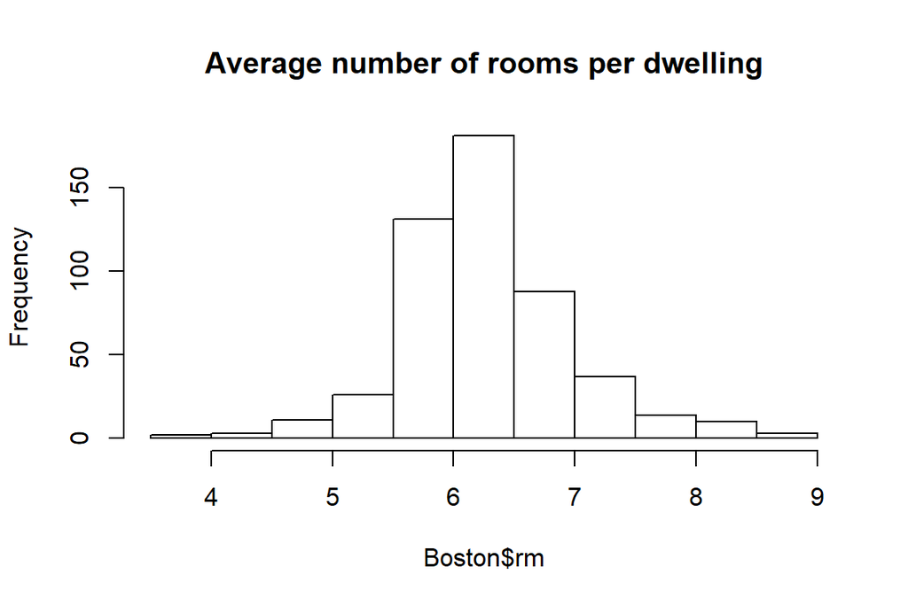

```r
hist(Boston$rm,main="Average number of rooms per dwelling")
```

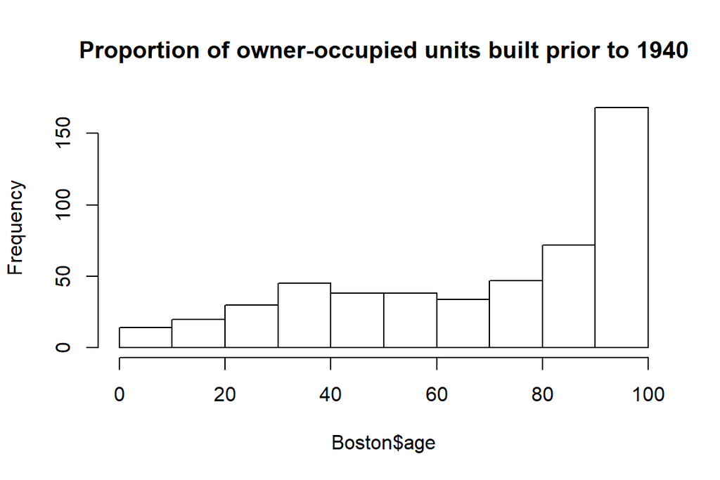

```r
hist(Boston$age,main="Proportion of owner-occupied units built prior to 1940")
```

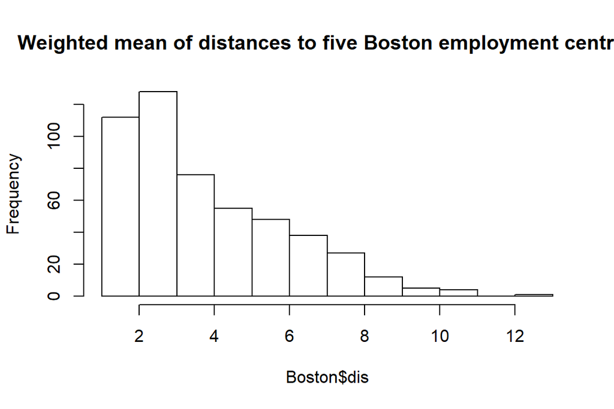

```r
hist(Boston$dis,main="Weighted mean of distances to five Boston employment centres")
```

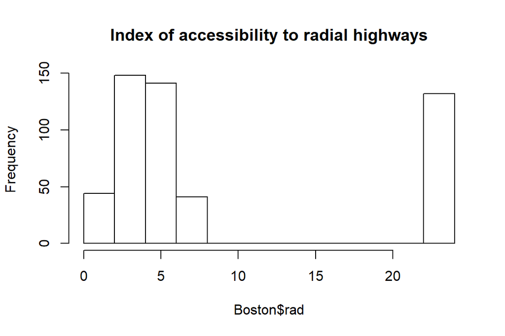

```r
hist(Boston$rad,main="Index of accessibility to radial highways")
```

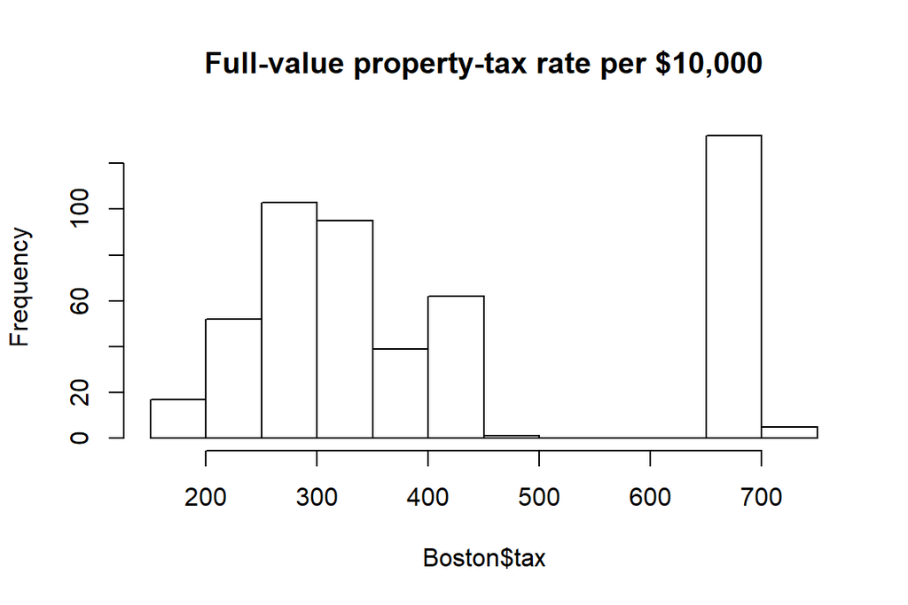

```r
hist(Boston$tax,main="Full-value property-tax rate per $10,000")
```

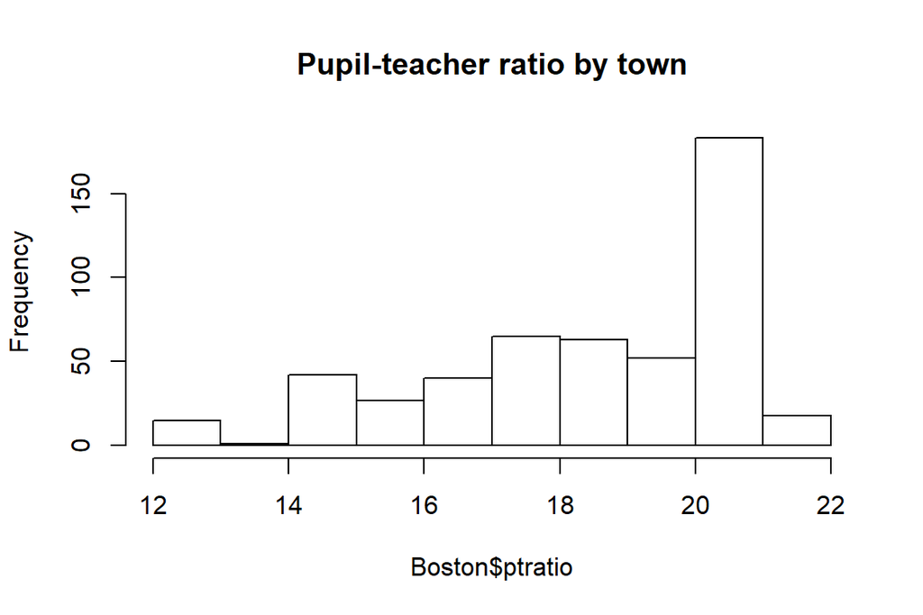

```r
hist(Boston$ptratio,main="Pupil-teacher ratio by town")
```

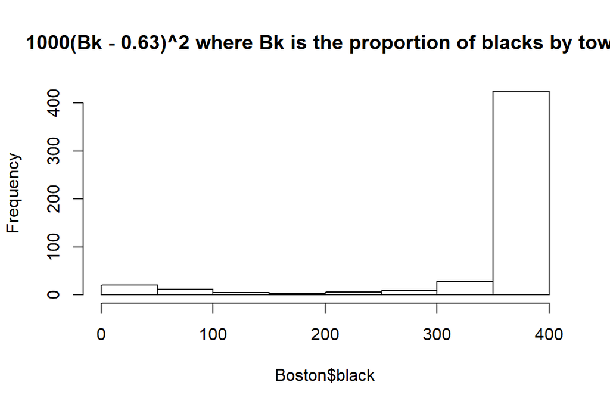

```r
hist(Boston$black,main="1000(Bk - 0.63)^2 where Bk is the proportion of blacks by town")
```

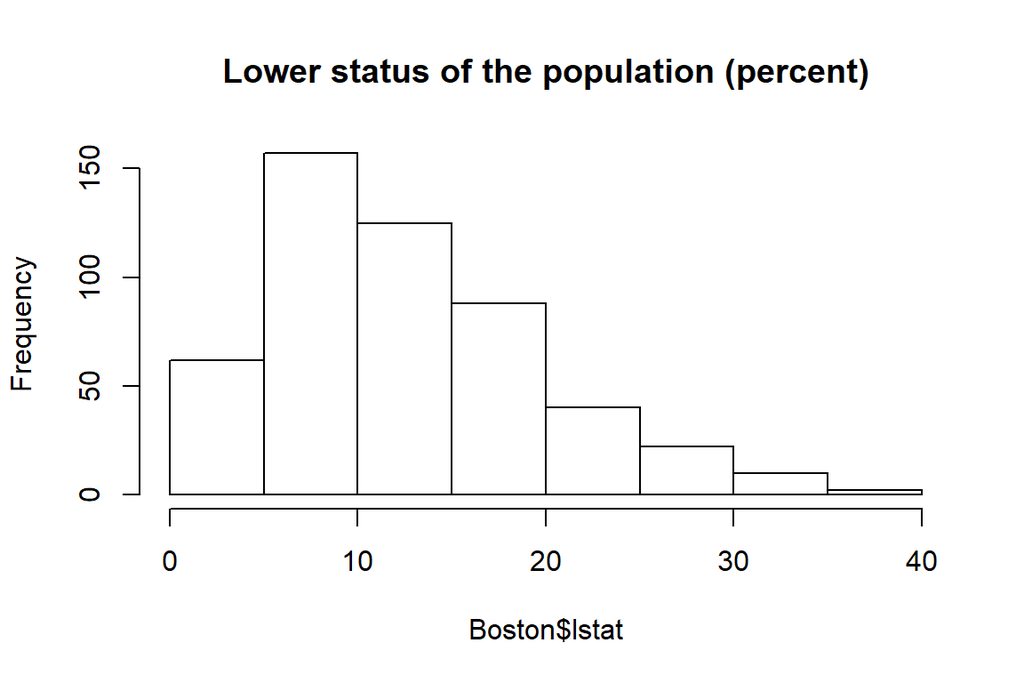

```r
hist(Boston$lstat,main="Lower status of the population (percent)")
```

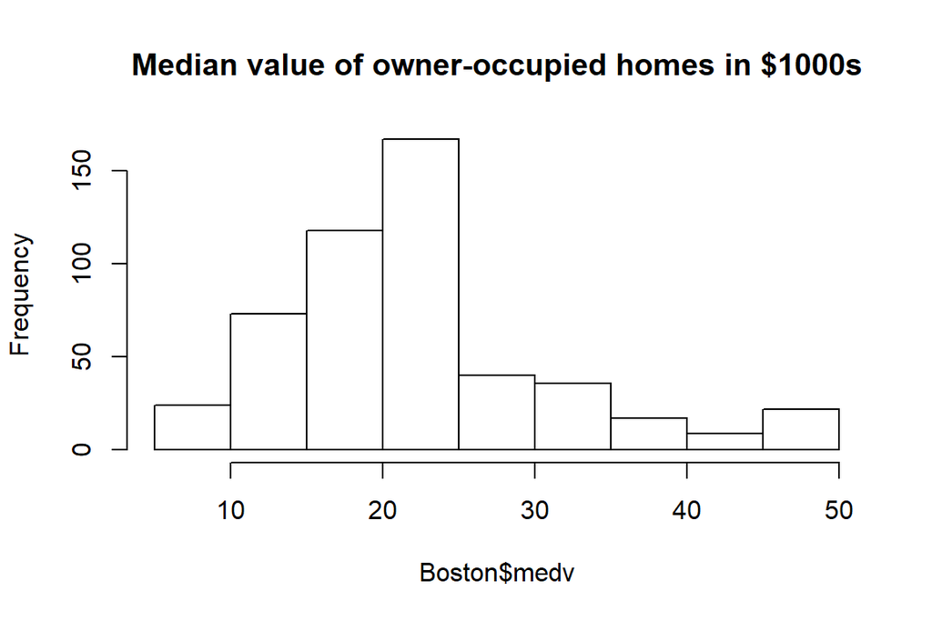

```r
hist(Boston$medv,main="Median value of owner-occupied homes in $1000s")
```

```r
#Summaries of the variables:
summary(Boston)
```

```
##       crim                zn             indus            chas
##  Min.   : 0.00632   Min.   :  0.00   Min.   : 0.46   Min.   :0.00000
##  1st Qu.: 0.08204   1st Qu.:  0.00   1st Qu.: 5.19   1st Qu.:0.00000
##  Median : 0.25651   Median :  0.00   Median : 9.69   Median :0.00000
##  Mean   : 3.61352   Mean   : 11.36   Mean   :11.14   Mean   :0.06917
##  3rd Qu.: 3.67708   3rd Qu.: 12.50   3rd Qu.:18.10   3rd Qu.:0.00000
##  Max.   :88.97620   Max.   :100.00   Max.   :27.74   Max.   :1.00000
##       nox               rm             age              dis
##  Min.   :0.3850   Min.   :3.561   Min.   :  2.90   Min.   : 1.130
##  1st Qu.:0.4490   1st Qu.:5.886   1st Qu.: 45.02   1st Qu.: 2.100
##  Median :0.5380   Median :6.208   Median : 77.50   Median : 3.207
##  Mean   :0.5547   Mean   :6.285   Mean   : 68.57   Mean   : 3.795
##  3rd Qu.:0.6240   3rd Qu.:6.623   3rd Qu.: 94.08   3rd Qu.: 5.188
##  Max.   :0.8710   Max.   :8.780   Max.   :100.00   Max.   :12.127
##       rad              tax           ptratio          black
##  Min.   : 1.000   Min.   :187.0   Min.   :12.60   Min.   :  0.32
##  1st Qu.: 4.000   1st Qu.:279.0   1st Qu.:17.40   1st Qu.:375.38
##  Median : 5.000   Median :330.0   Median :19.05   Median :391.44
##  Mean   : 9.549   Mean   :408.2   Mean   :18.46   Mean   :356.67
##  3rd Qu.:24.000   3rd Qu.:666.0   3rd Qu.:20.20   3rd Qu.:396.23
##  Max.   :24.000   Max.   :711.0   Max.   :22.00   Max.   :396.90
##      lstat            medv
##  Min.   : 1.73   Min.   : 5.00
##  1st Qu.: 6.95   1st Qu.:17.02
##  Median :11.36   Median :21.20
##  Mean   :12.65   Mean   :22.53
##  3rd Qu.:16.95   3rd Qu.:25.00
##  Max.   :37.97   Max.   :50.00
```

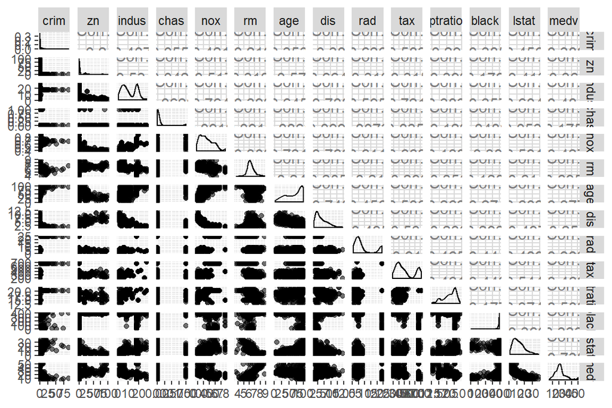

```r
#Correlations between the variables:
matrix <- ggpairs(Boston, mapping = aes(alpha = 0.3), lower = list(combo = wrap("facethist", bins = 20)))
matrix
```

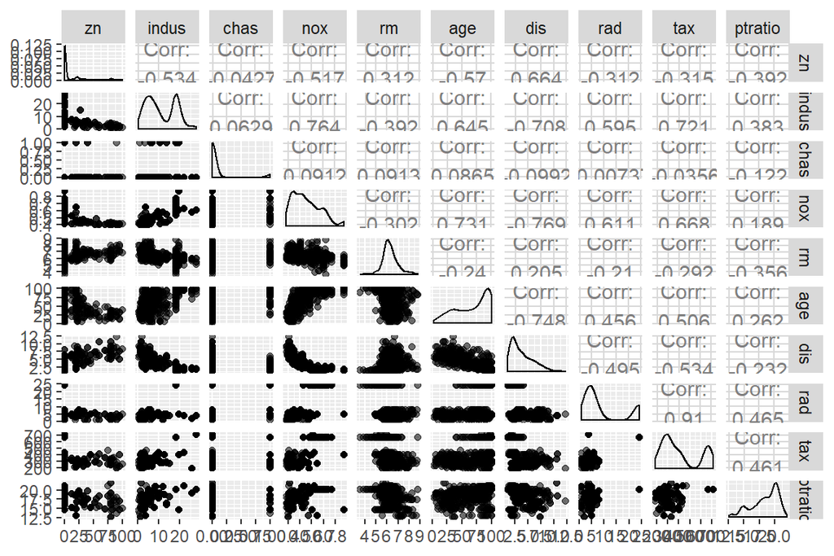

```r
#Inspecting more closely the relationships between specific promising variables (vars showing good correlation with other vars):
promise <- c(Boston$zn, Boston$indus, Boston$nox, Boston$rm, Boston$ptratio, Boston$lstat)
matrix2 <- ggpairs(Boston, columns=2:11, mapping = aes(alpha = 0.3), lower = list(combo = wrap("facethist", bins = 20)))
matrix2
```

Overall, we can see that many variables in this dataset are skewed in distribution. The outputs show us e.g. that in most areas, per capita crime rate is very low (Md=0.26, range 0.01-88.98), as is the proportion of residential land zoned for lots over 25,000 square feet (Md=0.00, range0.00-100.00) (i.e. in almost all areas, families tend to live within smaller lots than around 2,300 square meters). Many areas have around 20% proportion of non-retail business acres (range 0.46-27.74%). In half of the areas studied, nitrogen oxides concentration is lower than 0.54 parts per 10 million (range 0.39-0.87). I most areas, the average number of rooms per dwelling is around six (range 3.56-8.78). The most common pupil-teacher ratio is around 20 (20 pupils per teacher), ranging from 12.60 to 22.00.

Strong correlations can also be seen between the variables indus and tax (the greater the proportion of non-retail industry acres, the greater the full-value property-tax rate, r=0.721) and indus and dis (the greater the proportion of non-retail industry acres, the smaller the distances to employment centers, r=-0.708).

In short, the air quality seems to be worst nearest to the employment centers, old buildings and non-retail industry; and non-retail industry tend to be located near the employment centers and have higher property taxes.

## TASK 4

## Standardizing the dataset, creating a new categorical var and dividing the dataset

In order to conduct the linear discriminant analysis, we need to scale the data first. This is because of the underlying assumptions that each variable has the same variance and that variables are normally distributed. We also need to have a categorical variable as the outcome variable, so we need to categorize the continuous variable “crim”.

```r
#Positioning each variable so on the x axis that the mean is 0 -> saving to an object:
Boston_scaled <- scale(Boston)

#Summaries of the scaled vars:
summary(Boston_scaled)
```

```
##       crim                 zn               indus
##  Min.   :-0.419367   Min.   :-0.48724   Min.   :-1.5563
##  1st Qu.:-0.410563   1st Qu.:-0.48724   1st Qu.:-0.8668
##  Median :-0.390280   Median :-0.48724   Median :-0.2109
##  Mean   : 0.000000   Mean   : 0.00000   Mean   : 0.0000
##  3rd Qu.: 0.007389   3rd Qu.: 0.04872   3rd Qu.: 1.0150
##  Max.   : 9.924110   Max.   : 3.80047   Max.   : 2.4202
##       chas              nox                rm               age
##  Min.   :-0.2723   Min.   :-1.4644   Min.   :-3.8764   Min.   :-2.3331
##  1st Qu.:-0.2723   1st Qu.:-0.9121   1st Qu.:-0.5681   1st Qu.:-0.8366
##  Median :-0.2723   Median :-0.1441   Median :-0.1084   Median : 0.3171
##  Mean   : 0.0000   Mean   : 0.0000   Mean   : 0.0000   Mean   : 0.0000
##  3rd Qu.:-0.2723   3rd Qu.: 0.5981   3rd Qu.: 0.4823   3rd Qu.: 0.9059
##  Max.   : 3.6648   Max.   : 2.7296   Max.   : 3.5515   Max.   : 1.1164
##       dis               rad               tax             ptratio
##  Min.   :-1.2658   Min.   :-0.9819   Min.   :-1.3127   Min.   :-2.7047
##  1st Qu.:-0.8049   1st Qu.:-0.6373   1st Qu.:-0.7668   1st Qu.:-0.4876
##  Median :-0.2790   Median :-0.5225   Median :-0.4642   Median : 0.2746
##  Mean   : 0.0000   Mean   : 0.0000   Mean   : 0.0000   Mean   : 0.0000
##  3rd Qu.: 0.6617   3rd Qu.: 1.6596   3rd Qu.: 1.5294   3rd Qu.: 0.8058
##  Max.   : 3.9566   Max.   : 1.6596   Max.   : 1.7964   Max.   : 1.6372
##      black             lstat              medv
##  Min.   :-3.9033   Min.   :-1.5296   Min.   :-1.9063
##  1st Qu.: 0.2049   1st Qu.:-0.7986   1st Qu.:-0.5989
##  Median : 0.3808   Median :-0.1811   Median :-0.1449
##  Mean   : 0.0000   Mean   : 0.0000   Mean   : 0.0000
##  3rd Qu.: 0.4332   3rd Qu.: 0.6024   3rd Qu.: 0.2683
##  Max.   : 0.4406   Max.   : 3.5453   Max.   : 2.9865
```

```r
#Changing the object to a data frame:
Boston_scaled <- as.data.frame(Boston_scaled)
```

We can see that while the mean of every variable is 0.00, distribution of many variables still varies from normal - this may be problematic for the assumptions of the linear discriminant analysis.

```r
#Creating a categorical variable of the crime rate using the quantiles as the break points:
quantile_vector <- quantile(Boston_scaled$crim) #creating a vector for the quantiles
quantile_vector #checking the break points
```

```
##           0%          25%          50%          75%         100%
## -0.419366929 -0.410563278 -0.390280295  0.007389247  9.924109610
```

```r
crime_categ <- cut(Boston_scaled$crim, breaks = quantile_vector, include.lowest = TRUE) #Creating the new var with 4 levels

#Dropping the old continuous crime rate var ("crim") from the dataset and adding the new categorical one ("crime_categ"):
Boston_scaled <- dplyr::select(Boston_scaled, -crim)
Boston_scaled <- data.frame(Boston_scaled, crime_categ)
summary(Boston_scaled)
```

```
##        zn               indus              chas              nox
##  Min.   :-0.48724   Min.   :-1.5563   Min.   :-0.2723   Min.   :-1.4644
##  1st Qu.:-0.48724   1st Qu.:-0.8668   1st Qu.:-0.2723   1st Qu.:-0.9121
##  Median :-0.48724   Median :-0.2109   Median :-0.2723   Median :-0.1441
##  Mean   : 0.00000   Mean   : 0.0000   Mean   : 0.0000   Mean   : 0.0000
##  3rd Qu.: 0.04872   3rd Qu.: 1.0150   3rd Qu.:-0.2723   3rd Qu.: 0.5981
##  Max.   : 3.80047   Max.   : 2.4202   Max.   : 3.6648   Max.   : 2.7296
##        rm               age               dis               rad
##  Min.   :-3.8764   Min.   :-2.3331   Min.   :-1.2658   Min.   :-0.9819
##  1st Qu.:-0.5681   1st Qu.:-0.8366   1st Qu.:-0.8049   1st Qu.:-0.6373
##  Median :-0.1084   Median : 0.3171   Median :-0.2790   Median :-0.5225
##  Mean   : 0.0000   Mean   : 0.0000   Mean   : 0.0000   Mean   : 0.0000
##  3rd Qu.: 0.4823   3rd Qu.: 0.9059   3rd Qu.: 0.6617   3rd Qu.: 1.6596
##  Max.   : 3.5515   Max.   : 1.1164   Max.   : 3.9566   Max.   : 1.6596
##       tax             ptratio            black             lstat
##  Min.   :-1.3127   Min.   :-2.7047   Min.   :-3.9033   Min.   :-1.5296
##  1st Qu.:-0.7668   1st Qu.:-0.4876   1st Qu.: 0.2049   1st Qu.:-0.7986
##  Median :-0.4642   Median : 0.2746   Median : 0.3808   Median :-0.1811
##  Mean   : 0.0000   Mean   : 0.0000   Mean   : 0.0000   Mean   : 0.0000
##  3rd Qu.: 1.5294   3rd Qu.: 0.8058   3rd Qu.: 0.4332   3rd Qu.: 0.6024
##  Max.   : 1.7964   Max.   : 1.6372   Max.   : 0.4406   Max.   : 3.5453
##       medv                  crime_categ
##  Min.   :-1.9063   [-0.419,-0.411]:127
##  1st Qu.:-0.5989   (-0.411,-0.39] :126
##  Median :-0.1449   (-0.39,0.00739]:126
##  Mean   : 0.0000   (0.00739,9.92] :127
##  3rd Qu.: 0.2683
##  Max.   : 2.9865
```

Now we can see that the new crime_categ variable has four levels, and each level has 126 or 127 cases.

We are about to create a model and train it using one subset of the data (80%) and to test the predictive power of the model using another subset (20%). Therefore, the dataset needs to be split in two.

```r
row_n <- nrow(Boston_scaled)  #saving the number of rows
chosen_rows <- sample(row_n, size = row_n * 0.8) #Choosing randomly 80% of the rows

#Dividing the data set to train and test sets:
train <- Boston_scaled[chosen_rows,]
test <- Boston_scaled[-chosen_rows,]
```

## TASK 5

## Fitting the linear discriminant analysis (LDA) on the train set and drawing the LDA biplot

We use the categorical crime rate variable as the target variable and all the other vars as predictor variables.

```r
library(dplyr)

lda.fit <- lda(crime_categ ~ ., data = train) #Using the train set for the analysis
lda.fit
```

```
## Call:
## lda(crime_categ ~ ., data = train)
##
## Prior probabilities of groups:
## [-0.419,-0.411]  (-0.411,-0.39] (-0.39,0.00739]  (0.00739,9.92]
##       0.2599010       0.2500000       0.2351485       0.2549505
##
## Group means:
##                          zn      indus          chas        nox
## [-0.419,-0.411]  0.97691194 -0.9337042 -0.1223442968 -0.8889654
## (-0.411,-0.39]  -0.09285544 -0.2491929  0.0005392655 -0.5361749
## (-0.39,0.00739] -0.39606985  0.1596757  0.2664320172  0.3906996
## (0.00739,9.92]  -0.48724019  1.0170891 -0.0429834229  1.0549632
##                          rm        age        dis        rad        tax
## [-0.419,-0.411]  0.47255146 -0.8941458  0.8976179 -0.6931138 -0.7436486
## (-0.411,-0.39]  -0.11804625 -0.3367053  0.3157670 -0.5452263 -0.4264979
## (-0.39,0.00739]  0.09782573  0.4389387 -0.3832999 -0.4185179 -0.3223734
## (0.00739,9.92]  -0.40909934  0.8301514 -0.8622108  1.6384176  1.5142626
##                     ptratio       black        lstat        medv
## [-0.419,-0.411] -0.43740693  0.38710952 -0.785959768  0.53770066
## (-0.411,-0.39]  -0.05537785  0.31880843 -0.119971885 -0.01422471
## (-0.39,0.00739] -0.24055883  0.06355773 -0.009553361  0.12599321
## (0.00739,9.92]   0.78111358 -0.84850797  0.911254594 -0.67114736
##
## Coefficients of linear discriminants:
##                 LD1         LD2         LD3
## zn       0.10782141  0.61997807 -0.89960742
## indus    0.04523563 -0.34356453  0.35683708
## chas    -0.08948257 -0.07574563  0.09685651
## nox      0.43501975 -0.68288194 -1.33413780
## rm      -0.13418049 -0.06223355 -0.13007933
## age      0.22617756 -0.39555174 -0.31620837
## dis     -0.01367701 -0.18914923  0.13983328
## rad      3.43197627  0.81751850 -0.28722941
## tax     -0.03278370  0.23239640  0.77141284
## ptratio  0.13916491 -0.01149882 -0.25588287
## black   -0.12312805  0.03022107  0.14395843
## lstat    0.30470478 -0.11074911  0.55502267
## medv     0.26241812 -0.27707353 -0.07387986
##
## Proportion of trace:
##    LD1    LD2    LD3
## 0.9548 0.0334 0.0117
```

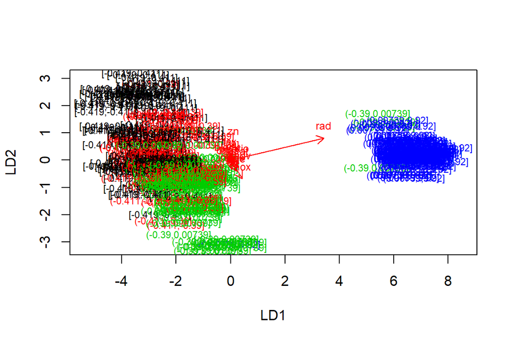

```r
#The function for lda biplot arrows:
lda.arrows <- function(x, myscale = 1, arrow_heads = 0.1, color = "red", tex = 0.75, choices = c(1,2)){
  heads <- coef(x)
  arrows(x0 = 0, y0 = 0,
         x1 = myscale * heads[,choices[1]],
         y1 = myscale * heads[,choices[2]], col=color, length = arrow_heads)
  text(myscale * heads[,choices], labels = row.names(heads),
       cex = tex, col=color, pos=3)
}

classes <- as.numeric(train$crime_categ)  #targeting classes as numeric

plot(lda.fit, dimen = 2, col = classes, pch = classes)
lda.arrows(lda.fit, myscale =1)
```

It seems that the category with highest crime rate (blue) is clearly separate from the other three categories. The categories with lowest (black) and second highest crime rate (green) are also rather well distinguishable.

## TASK 6

## Saving + removing the crime categories from the test set and predicting the outcomes in the test data

```r
#Saving the crime categories from the test subset as correct classes and then removing these categories from the test data:
correct_categ <- test$crime_categ
correct_categ #checking the saved categories
```

```
##   [1] [-0.419,-0.411] (-0.411,-0.39]  (-0.39,0.00739] (-0.39,0.00739]
##   [5] (-0.39,0.00739] (-0.411,-0.39]  [-0.419,-0.411] (-0.411,-0.39]
##   [9] (-0.411,-0.39]  (-0.411,-0.39]  (-0.411,-0.39]  (-0.411,-0.39]
##  [13] [-0.419,-0.411] [-0.419,-0.411] (-0.411,-0.39]  (-0.411,-0.39]
##  [17] (-0.411,-0.39]  (-0.411,-0.39]  [-0.419,-0.411] (-0.411,-0.39]
##  [21] (-0.411,-0.39]  (-0.39,0.00739] (-0.39,0.00739] (-0.39,0.00739]
##  [25] (-0.39,0.00739] (-0.39,0.00739] (-0.39,0.00739] (-0.39,0.00739]
##  [29] (-0.39,0.00739] (-0.39,0.00739] (-0.39,0.00739] (-0.39,0.00739]
##  [33] (-0.39,0.00739] (-0.411,-0.39]  [-0.419,-0.411] [-0.419,-0.411]
##  [37] (-0.411,-0.39]  (-0.411,-0.39]  [-0.419,-0.411] [-0.419,-0.411]
##  [41] [-0.419,-0.411] (-0.411,-0.39]  (-0.411,-0.39]  (-0.39,0.00739]
##  [45] (-0.39,0.00739] (-0.39,0.00739] (-0.411,-0.39]  (-0.411,-0.39]
##  [49] (-0.411,-0.39]  (-0.39,0.00739] [-0.419,-0.411] (-0.39,0.00739]
##  [53] (-0.39,0.00739] (-0.39,0.00739] (-0.39,0.00739] [-0.419,-0.411]
##  [57] (-0.411,-0.39]  [-0.419,-0.411] [-0.419,-0.411] [-0.419,-0.411]
##  [61] (-0.411,-0.39]  [-0.419,-0.411] [-0.419,-0.411] [-0.419,-0.411]
##  [65] (-0.39,0.00739] (-0.39,0.00739] (-0.39,0.00739] (-0.411,-0.39]
##  [69] (-0.39,0.00739] (-0.39,0.00739] (-0.39,0.00739] (-0.411,-0.39]
##  [73] [-0.419,-0.411] [-0.419,-0.411] [-0.419,-0.411] (0.00739,9.92]
##  [77] (0.00739,9.92]  (0.00739,9.92]  (0.00739,9.92]  (0.00739,9.92]
##  [81] (0.00739,9.92]  (0.00739,9.92]  (0.00739,9.92]  (0.00739,9.92]
##  [85] (0.00739,9.92]  (0.00739,9.92]  (0.00739,9.92]  (0.00739,9.92]
##  [89] (0.00739,9.92]  (0.00739,9.92]  (0.00739,9.92]  (0.00739,9.92]
##  [93] (0.00739,9.92]  (0.00739,9.92]  (-0.39,0.00739] (0.00739,9.92]
##  [97] (0.00739,9.92]  (-0.39,0.00739] (0.00739,9.92]  (0.00739,9.92]
## [101] (0.00739,9.92]  [-0.419,-0.411]
## 4 Levels: [-0.419,-0.411] (-0.411,-0.39] ... (0.00739,9.92]
```

```r
test <- dplyr::select(test, -crime_categ)

#Predicting the classes (crime categories) using the LDA model:
lda.pred <- predict(lda.fit, newdata = test)  #saving the predictions into a new object

table(correct = correct_categ, predicted = lda.pred$class)
```

```
##                  predicted
## correct           [-0.419,-0.411] (-0.411,-0.39] (-0.39,0.00739]
##   [-0.419,-0.411]              12              8               2
##   (-0.411,-0.39]                4             18               3
##   (-0.39,0.00739]               0              8              21
##   (0.00739,9.92]                0              0               0
##                  predicted
## correct           (0.00739,9.92]
##   [-0.419,-0.411]              0
##   (-0.411,-0.39]               0
##   (-0.39,0.00739]              2
##   (0.00739,9.92]              24
```

## TASK 7

## Using the clustering approach to the observations in the Boston dataset

```r
#Reloading and standardizing the Boston dataset
data("Boston") #loading the data, MASS package available

#Positioning each variable so on the x axis that the mean is 0 -> saving to an object:
Boston_scaled2 <- scale(Boston)

#Summaries of the scaled vars:
summary(Boston_scaled2)
```

```
##       crim                 zn               indus
##  Min.   :-0.419367   Min.   :-0.48724   Min.   :-1.5563
##  1st Qu.:-0.410563   1st Qu.:-0.48724   1st Qu.:-0.8668
##  Median :-0.390280   Median :-0.48724   Median :-0.2109
##  Mean   : 0.000000   Mean   : 0.00000   Mean   : 0.0000
##  3rd Qu.: 0.007389   3rd Qu.: 0.04872   3rd Qu.: 1.0150
##  Max.   : 9.924110   Max.   : 3.80047   Max.   : 2.4202
##       chas              nox                rm               age
##  Min.   :-0.2723   Min.   :-1.4644   Min.   :-3.8764   Min.   :-2.3331
##  1st Qu.:-0.2723   1st Qu.:-0.9121   1st Qu.:-0.5681   1st Qu.:-0.8366
##  Median :-0.2723   Median :-0.1441   Median :-0.1084   Median : 0.3171
##  Mean   : 0.0000   Mean   : 0.0000   Mean   : 0.0000   Mean   : 0.0000
##  3rd Qu.:-0.2723   3rd Qu.: 0.5981   3rd Qu.: 0.4823   3rd Qu.: 0.9059
##  Max.   : 3.6648   Max.   : 2.7296   Max.   : 3.5515   Max.   : 1.1164
##       dis               rad               tax             ptratio
##  Min.   :-1.2658   Min.   :-0.9819   Min.   :-1.3127   Min.   :-2.7047
##  1st Qu.:-0.8049   1st Qu.:-0.6373   1st Qu.:-0.7668   1st Qu.:-0.4876
##  Median :-0.2790   Median :-0.5225   Median :-0.4642   Median : 0.2746
##  Mean   : 0.0000   Mean   : 0.0000   Mean   : 0.0000   Mean   : 0.0000
##  3rd Qu.: 0.6617   3rd Qu.: 1.6596   3rd Qu.: 1.5294   3rd Qu.: 0.8058
##  Max.   : 3.9566   Max.   : 1.6596   Max.   : 1.7964   Max.   : 1.6372
##      black             lstat              medv
##  Min.   :-3.9033   Min.   :-1.5296   Min.   :-1.9063
##  1st Qu.: 0.2049   1st Qu.:-0.7986   1st Qu.:-0.5989
##  Median : 0.3808   Median :-0.1811   Median :-0.1449
##  Mean   : 0.0000   Mean   : 0.0000   Mean   : 0.0000
##  3rd Qu.: 0.4332   3rd Qu.: 0.6024   3rd Qu.: 0.2683
##  Max.   : 0.4406   Max.   : 3.5453   Max.   : 2.9865
```

```r
#Changing the object to a data frame:
Boston_scaled2 <- as.data.frame(Boston_scaled2)

#Calculating the distances (similarity/dissimilarity) between observations)
dist_eu <- dist(Boston_scaled2)  #euclidean distance matrix calculates the usual distance between two vectors
dist_man <- dist(Boston_scaled2, method = "manhattan")  #manhattan distance matrix calculates the absolute distance between two vectors

summary(dist_man)
```

```
##    Min. 1st Qu.  Median    Mean 3rd Qu.    Max.
##  0.2662  8.4832 12.6090 13.5488 17.7568 48.8618
```

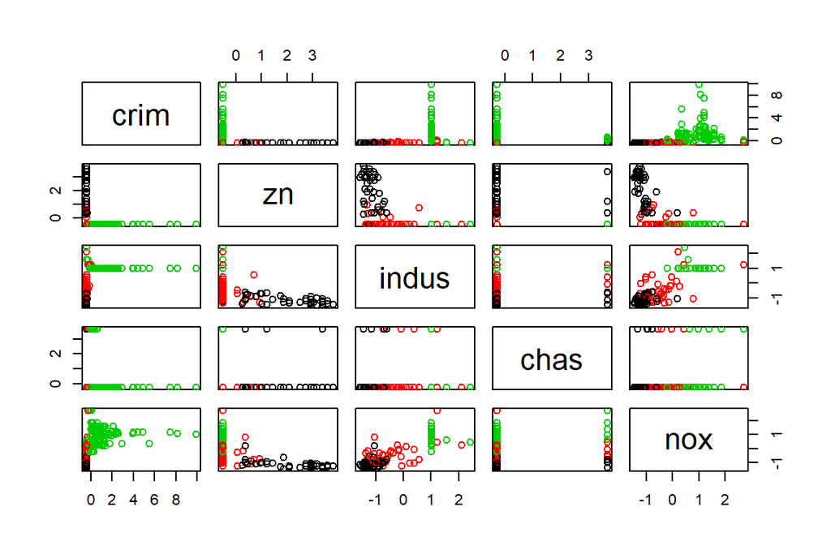

```r
#Running k-means algorithm as a clustering method

km <-kmeans(Boston_scaled2, centers = 3) #k-means clustering

pairs(Boston_scaled2[1:5], col = km$cluster) #plotting the Boston dataset with clusters
```

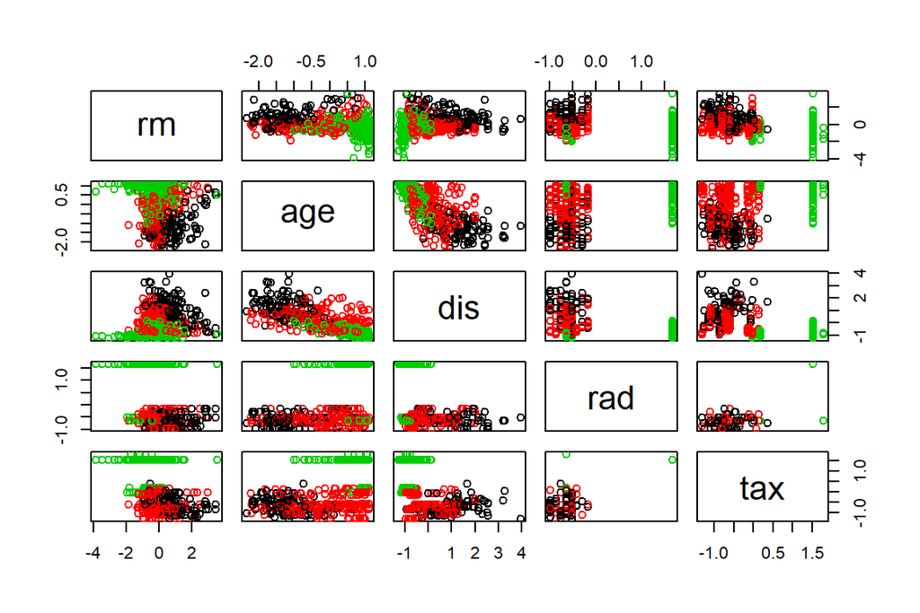

```r
pairs(Boston_scaled2[6:10], col = km$cluster)
```

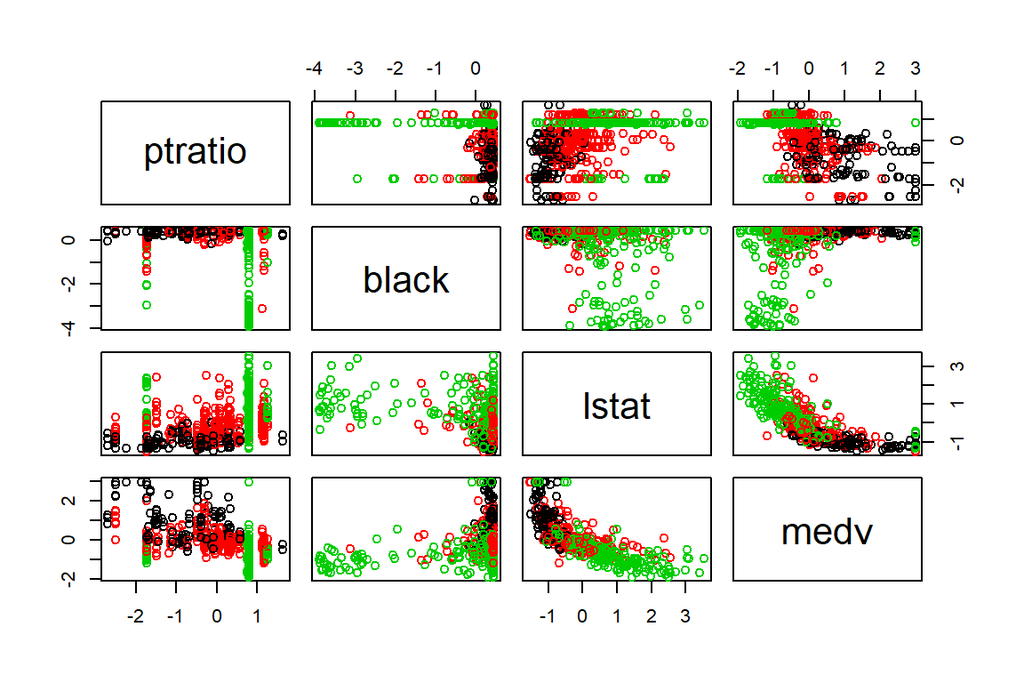

```r
pairs(Boston_scaled2[11:14], col = km$cluster)
```

The k-means clustering method assigns observations to clusters based on similarity of the objects. I ran the analysis with 3, 4, and 5 centers. Judged by the visualizations, the three-center solution seems to produce the most differing categories, and therefore I would try clustering the data into 3 groups. Based solely on the visualizations, among the most promising-looking variables for maximizing the distance between clusters are per capita crime rate (crim), proportion of non-retail business acres in town (indus), air pollution (nox), proportion of owner-occupied old units (age) and distances to employment centers (dis). These results are rather well in line with the initial correlation results shown below Task 3.

# Exercise 6: Analysis

*In this week’s exercise, we explore the data using both simpler and more advanced methods (i.e. linear mixed effects models).*

Reading the long form data sets:

```r
BPRS_l <- read.table("data/BPRS2_long", sep = " ")
RATS_l <- read.table("data/RATS2_long", sep = " ")

str(BPRS_l)
```

```
## 'data.frame':    360 obs. of  5 variables:
##  $ treatment: int  1 1 1 1 1 1 1 1 1 1 ...
##  $ subject  : int  1 2 3 4 5 6 7 8 9 10 ...
##  $ weeks    : Factor w/ 9 levels "week0","week1",..: 1 1 1 1 1 1 1 1 1 1 ...
##  $ BPRS     : int  42 58 54 55 72 48 71 30 41 57 ...
##  $ week     : int  0 0 0 0 0 0 0 0 0 0 ...
```

```r
str(RATS_l)
```

```
## 'data.frame':    176 obs. of  5 variables:
##  $ ID   : int  1 2 3 4 5 6 7 8 9 10 ...
##  $ Group: int  1 1 1 1 1 1 1 1 2 2 ...
##  $ days : Factor w/ 11 levels "WD1","WD15","WD22",..: 1 1 1 1 1 1 1 1 1 1 ...
##  $ grams: int  240 225 245 260 255 260 275 245 410 405 ...
##  $ day  : int  1 1 1 1 1 1 1 1 1 1 ...
```

## TASK 1 Implementing the analyses of Chapter 8 of the text book using the RATS data

## Graphical display of the longitudinal data

Let’s plot the weight values across time in all diet groups for each rat.

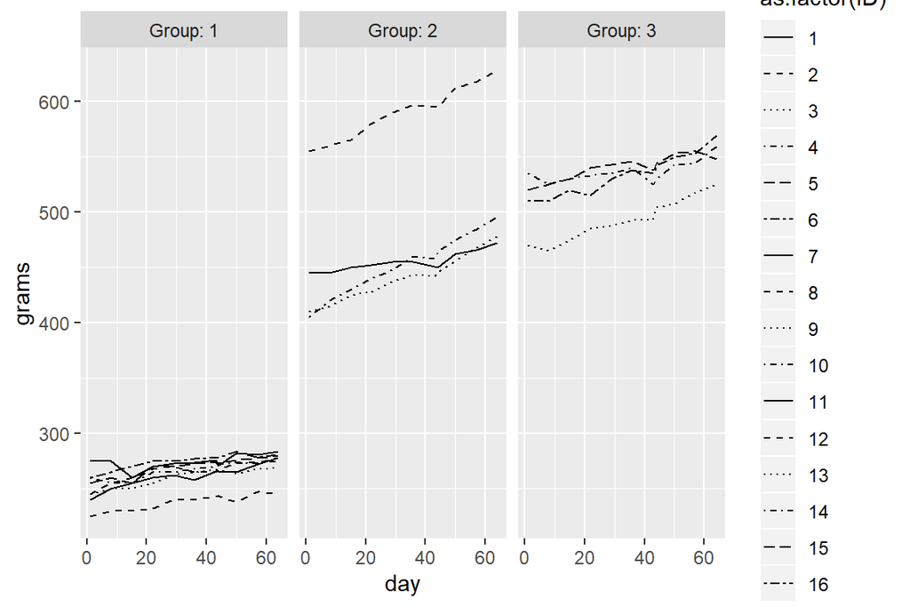

```r
library(ggplot2)
library(dplyr)

ggplot(RATS_l, aes(x = day, y = grams, linetype = as.factor(ID))) +   #treating the ID variable as factor
  geom_line() +
  scale_linetype_manual(values = rep(1:10, times=4)) +
  facet_grid(. ~ Group, labeller = label_both)
```

As we can see, all rats in all groups gained weight over time. In the first diet group, however, the rats were smaller than in the other two groups to begin with, and in group 2, one rat was markedly heavier than others from the start. We want to take this initial variation into account when examining weight gain in these groups.

This variation can be seen also by standardizing the weight observations:

```r
RATS_l <- RATS_l %>%
  group_by(day) %>%
  mutate(stdgrams = (grams - mean(grams))/sd(grams)) %>%
  ungroup()

glimpse(RATS_l)
```

```
## Observations: 176
## Variables: 6
## $ ID       <int> 1, 2, 3, 4, 5, 6, 7, 8, 9, 10, 11, 12, 13, 14, 15, 16...
## $ Group    <int> 1, 1, 1, 1, 1, 1, 1, 1, 2, 2, 2, 2, 3, 3, 3, 3, 1, 1,...
## $ days     <fct> WD1, WD1, WD1, WD1, WD1, WD1, WD1, WD1, WD1, WD1, WD1...
## $ grams    <int> 240, 225, 245, 260, 255, 260, 275, 245, 410, 405, 445...
## $ day      <int> 1, 1, 1, 1, 1, 1, 1, 1, 1, 1, 1, 1, 1, 1, 1, 1, 8, 8,...
## $ stdgrams <dbl> -1.0011429, -1.1203857, -0.9613953, -0.8421525, -0.88...
```

Plots with the standardized data:

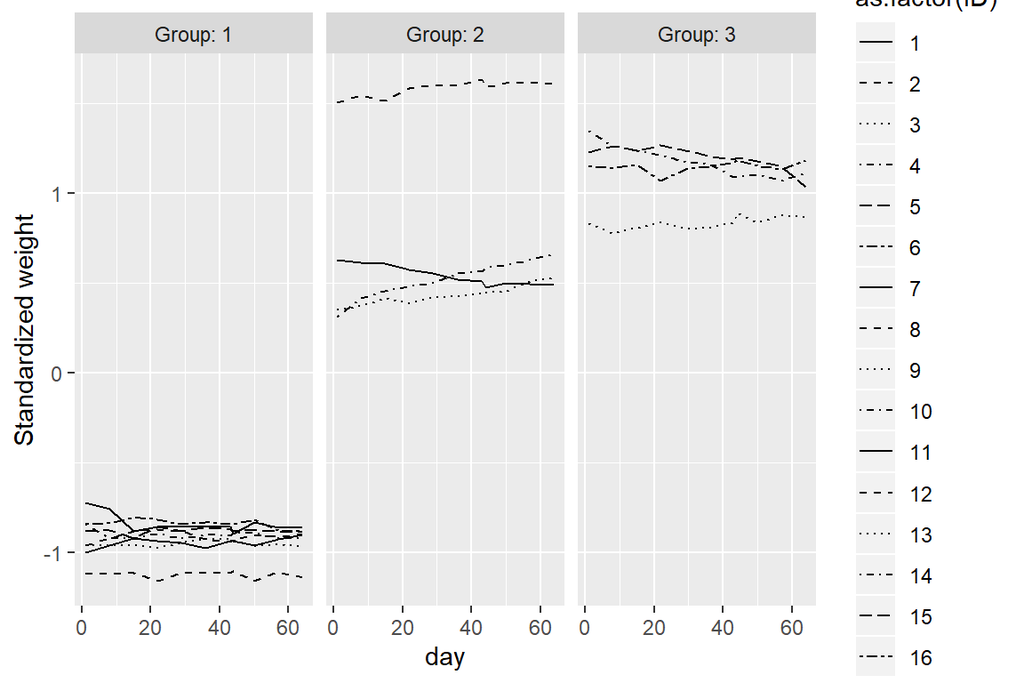

```r
ggplot(RATS_l, aes(x = day, y = stdgrams, linetype = as.factor(ID))) +   #treating the ID variable as factor
  geom_line() +
  scale_linetype_manual(values = rep(1:10, times=4)) +
  facet_grid(. ~ Group, labeller = label_both) +
  scale_y_continuous(name = "Standardized weight")
```

In this case, summary graphs may not help much in the interpretation of the data, for there are so few observations per group. However, here is a summary graph of the group-wise mean weight (unstandardized):

```r
#Creating the summary data:
RATS_S <- RATS_l %>%
  group_by(Group, ID) %>%
  summarise( mean=mean(grams) ) %>%
  ungroup()

glimpse(RATS_S)
```

```
## Observations: 16
## Variables: 3
## $ Group <int> 1, 1, 1, 1, 1, 1, 1, 1, 2, 2, 2, 2, 3, 3, 3, 3
## $ ID    <int> 1, 2, 3, 4, 5, 6, 7, 8, 9, 10, 11, 12, 13, 14, 15, 16
## $ mean  <dbl> 261.0909, 237.6364, 260.1818, 266.5455, 269.4545, 274.72...
```

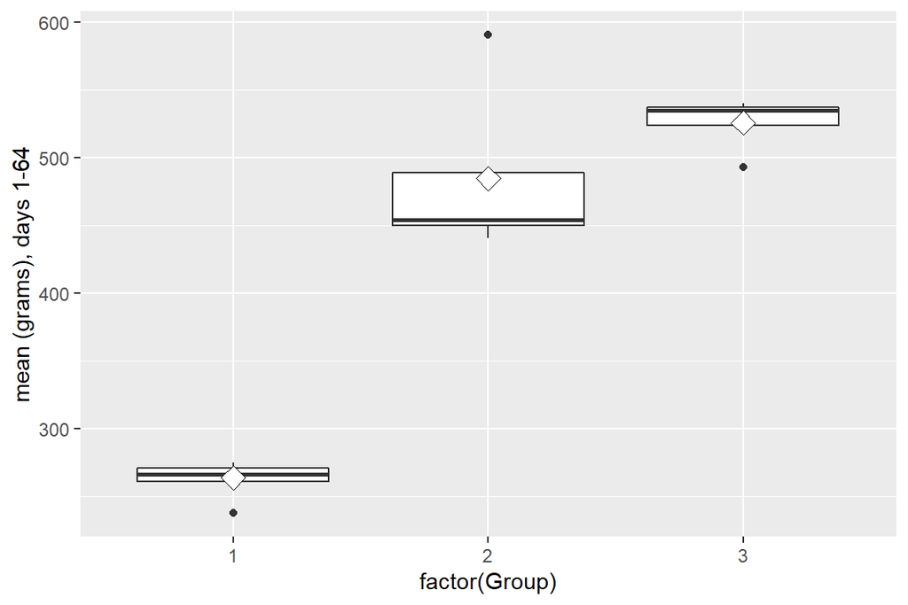

```r
#Drawing a boxplot of the mean weight versus diet group
ggplot(RATS_S, aes(x = factor(Group), y = mean)) +
  geom_boxplot() +
  stat_summary(fun.y = "mean", geom = "point", shape=23, size=4, fill = "white") +
  scale_y_continuous(name = "mean (grams), days 1-64")
```

This plot confirms that rats in group 1 were lighter than the others on average (across the whole study period). Group 3, on the contrary, seems to have most weight on average. It is noteworthy that due to a small sample size per group (n=4 to n = 8), the program easily interprets individual rats as outliers. Based on visual assessment, I would consider the outlier in group 2 a “true” outlier and remove it from the analysis.

To examine the statistical difference in mean weight between groups, the ANOVA (analysis of variance) could be used.

## TASK 2 Implementing the analyses of chapter 9 of the text book using the BPRS data

We expect the repeated measurements in the data set to be correlated (they’re taken from the same person). Therefore, we need a model that can take this into account. Here, we use a linear mixed effect model.

## Graphical display of the longitudinal data

Let’s plot the BPRS scores across time in both intervention settings for each participant.

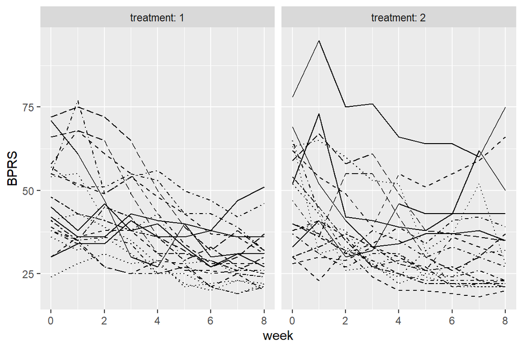

```r
#Drawing the plot of individual BPRS scores across time
ggplot(BPRS_l, aes(x = week, y = BPRS, linetype = as.factor(subject))) +
  geom_line() +
  scale_linetype_manual(values = rep(1:10, times=4)) +
  facet_grid(. ~ treatment, labeller = label_both) +
  theme(legend.position = "none") +
  scale_y_continuous(limits = c(min(BPRS_l$BPRS), max(BPRS_l$BPRS)))
```

For most participants, the psychiatric symptoms - measured by BPRS score - decreased over time.

There is variation between individuals that the linear mixed effects model interprets as random variation - hence the inclusion of random effects in the model. We can assume having random intercept (i.e. the starting level varies) and/or random slopes (i.e. the change across time varies) in the model, and based on the graph above, a model with random intercept and random slopes seems most appropriate.

We will compare models with 1) random intercept and 2) a combination of random intercept and random slopes.

```r
#Fitting the random intercept model to data:
library(lme4)
BPRS_m1 <- lmer(BPRS ~ week + treatment + (1 | subject), data = BPRS_l, REML = FALSE)

#summary of the model:
summary(BPRS_m1)
```

```
## Linear mixed model fit by maximum likelihood  ['lmerMod']
## Formula: BPRS ~ week + treatment + (1 | subject)
##    Data: BPRS_l
##
##      AIC      BIC   logLik deviance df.resid
##   2748.7   2768.1  -1369.4   2738.7      355
##
## Scaled residuals:
##     Min      1Q  Median      3Q     Max
## -3.0481 -0.6749 -0.1361  0.4813  3.4855
##
## Random effects:
##  Groups   Name        Variance Std.Dev.
##  subject  (Intercept)  47.41    6.885
##  Residual             104.21   10.208
## Number of obs: 360, groups:  subject, 20
##
## Fixed effects:
##             Estimate Std. Error t value
## (Intercept)  45.8817     2.4413  18.794
## week         -2.2704     0.2084 -10.896
## treatment     0.5722     1.0761   0.532
##
## Correlation of Fixed Effects:
##           (Intr) week
## week      -0.341
## treatment -0.661  0.000
```

```r
#Fitting the random intercept and random slopes model to data:
BPRS_m2 <- lmer(BPRS ~ week + treatment + (week | subject), data = BPRS_l, REML = FALSE)

#summary of the model:
summary(BPRS_m2)
```

```
## Linear mixed model fit by maximum likelihood  ['lmerMod']
## Formula: BPRS ~ week + treatment + (week | subject)
##    Data: BPRS_l
##
##      AIC      BIC   logLik deviance df.resid
##   2745.4   2772.6  -1365.7   2731.4      353
##
## Scaled residuals:
##     Min      1Q  Median      3Q     Max
## -2.8919 -0.6194 -0.0691  0.5531  3.7977
##
## Random effects:
##  Groups   Name        Variance Std.Dev. Corr
##  subject  (Intercept) 64.8222  8.0512
##           week         0.9609  0.9803   -0.51
##  Residual             97.4304  9.8707
## Number of obs: 360, groups:  subject, 20
##
## Fixed effects:
##             Estimate Std. Error t value
## (Intercept)  45.8817     2.5685  17.863
## week         -2.2704     0.2977  -7.626
## treatment     0.5722     1.0405   0.550
##
## Correlation of Fixed Effects:
##           (Intr) week
## week      -0.477
## treatment -0.608  0.000
```

According to the model fit indices, there is not much difference in how well these models fit the data. The residuals seem rather normally distributed in both models. Based on variance explained by intercept vs. week, the initial score on the BPRS scale seems to explain a great portion of the variance (compared with time). Still, the majority of the variance is left unexplained (residual).

Let’s test a third model with random intercept and slopes and a group x time interaction:

```r
#Fitting the random intercept and random slopes + interaction model to data:
BPRS_m3 <- lmer(BPRS ~ week * treatment + (week | subject), data = BPRS_l, REML = FALSE)

#summary of the model:
summary(BPRS_m3)
```

```
## Linear mixed model fit by maximum likelihood  ['lmerMod']
## Formula: BPRS ~ week * treatment + (week | subject)
##    Data: BPRS_l
##
##      AIC      BIC   logLik deviance df.resid
##   2744.3   2775.4  -1364.1   2728.3      352
##
## Scaled residuals:
##     Min      1Q  Median      3Q     Max
## -3.0513 -0.6270 -0.0768  0.5287  3.9259
##
## Random effects:
##  Groups   Name        Variance Std.Dev. Corr
##  subject  (Intercept) 65.0076  8.0627
##           week         0.9686  0.9842   -0.51
##  Residual             96.4708  9.8220
## Number of obs: 360, groups:  subject, 20
##
## Fixed effects:
##                Estimate Std. Error t value
## (Intercept)     50.1767     3.5159  14.271
## week            -3.3442     0.6711  -4.983
## treatment       -2.2911     1.9090  -1.200
## week:treatment   0.7158     0.4010   1.785
##
## Correlation of Fixed Effects:
##             (Intr) week   trtmnt
## week        -0.768
## treatment   -0.814  0.753
## week:trtmnt  0.684 -0.896 -0.840
```

This model doesn’t show much difference to the former models in terms of fit or the effect it explains. The interaction between time point and treatment doesn’t seem to bring additional value to the model.

Here - once more - is a plot from the data:

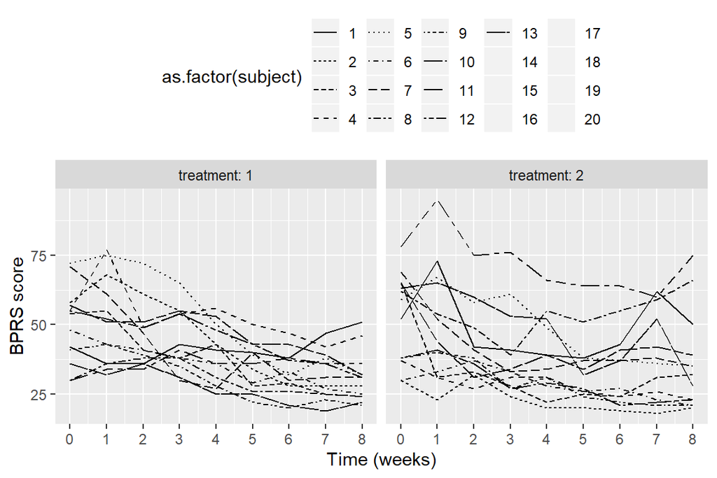

```r
ggplot(BPRS_l, aes(x = week, y = BPRS, group = subject)) +
  geom_line(aes(linetype = as.factor(subject))) +
  facet_grid(. ~ treatment, labeller = label_both) +
  scale_x_continuous(name = "Time (weeks)", breaks = seq(0, 10, 1)) +
  scale_y_continuous(name = "BPRS score") +
  theme(legend.position = "top")
```

In summary, according to these analyses, the initial score on the BPRS scale measuring psychiatric behavior disorders is the strongest determinant of the psychiatric behavior development over time. Most of the variance, however, is left unexplained by these models - we would have to include more variables to the model to test whether e.g. age shares part of this “unexplained” variance.